# Bayesilaiset Menetelmät

4/26/2019

## Bayesilaiset Menetelmät

- Todennäköisyys ja Bayesilainen tilastotiede
  - Bayesin kaava
  - Uskottavuusfunktio
  - Priorijakauma
  - Posteriorijakauma
- Todennäköisyysväli
- Mallien vertailu
- Prediktiiviset jakaumat
- Bayesilaiset menetelmät käytännössä
- **Kalvot löytyvät osoitteesta github.com/hpesonen**

## Todennäköisyys ja Bayesilainen tilastotiede

- Bayesiläisen tilastotieteen keskiössä on maailman mallittaminen
- Bayesilainen tilastotiede mallittaa todennäköisyyden epävarmuutena todellisuudesta
- 0 ja 1 ovat skaalan kaksi ääripäätä ja vastaavat täyttä varmuutta tapahtumasta
  - Epävarmuus on subjektiivinen käsite
  - **Maailman havannointi lisää informaatiota todellisuudesta ja vähentää epävarmuutta**

## Todennäköisyys ja Bayesilainen tilastotiede

- 0 ja 1 ovat skaalan kaksi ääripäätä ja vastaavat täyttä varmuutta tapahtumasta

[figure not shown]

## Todennäköisyys ja Bayesilainen tilastotiede

- Informaation lisäämisen mekanismi ilmaistaan Bayesin teoreeman avulla
  - Bayesin teoreema on siis **työkalu**, jota käytetään Bayesilaisessä analyysissä

\[p(\theta \mid y) = \frac{p(y \mid \theta)p(\theta)}{p(y)}\] - Bayesin teoreeman käyttö ei tee kenestäkään Bayesilaista, mutta epävarmuuden ilmaiseminen todennäköisyyden avulla tekee

## Bayesin teoreema

\[p(\theta \mid y) = \frac{p(y \mid \theta)p(\theta)}{p(y)}\]

- \(\theta\): Mallin parametrit
- \(y\): Data
- \(p(\theta \mid y)\): Posteriorijakauma
- \(p(y \mid \theta)\): Uskottavuusfunktio (Havaintomalli)
- \(p(\theta)\): Priorijakauma (Mitä havaintomallin arvot ovat realistisia)
- \(p(y)\): Evidenssi/Marginaali/Prioriprediktiivinen jakauma

## Esimerkki - Kolikonheitto

- Kolikonheitto on klassinen esimerkki informaation kertymisestä havaintoaineiston kasvaessa
- Tarkastellaan kolikkoa ja halutaan selvittää onko kolikko *reilu*
  - Merkitään parametrilla \(p\) todennäköisyyttä saada kolikonheitossa **klaava**
- Voidaan ajatella, että kolikonheitto on Bernoullin koe
  - Klaava (\(y=1\)) saadaan todennäköisyydellä \(\theta\), jolloin kruunan todennäköisyys on \(1-\theta\)
  - Uskottavuusfunktio Bernoullin kokeelle on

\[p(y \mid \theta) = \theta^y(1-\theta)^{1-y}\]

## Esimerkki - Kolikonheitto

- Toistettaessa riippumattomasti kolikonheitto-koetta \(N\) kertaa uskottavuusfunktio voidaan ilmaista muodossa

\[p(y_1, \ldots, y_N \mid \theta) = \prod_{i=1}^N p(y_i \mid \theta) = \theta^{\sum_{i} y_i} (1- \theta)^{N-\sum_{i}y_i} \]

## Esimerkki - Kolikonheitto

- Miten mallintaisimme epävarmuuttamme ennen ensimmäistäkään havaintopistettä?
  - Minkälainen priorijakauma vastaisi epävarmuuttamme klaavan esiintymisestä?

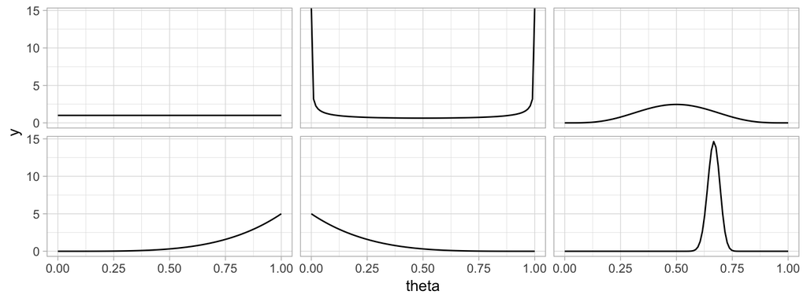

## Esimerkki - kolikonheitto

- Uskoaksemme on hyvin epätodennäköistä, että melko varmasti saataisiin aina \(0/1\)
- Uskoaksemme kolikko on melko todennäköisesti reilu (\(\theta=0.5\)), mutta emme voi poissulkea mahdollisuutta, että se ei ole
- Mallinnamme prioritietämystä jakaumalla \(p(\theta) \propto \theta^4(1-\theta)^4\) (\(\mathsf{Beta}(5,5)\)-jakauma)

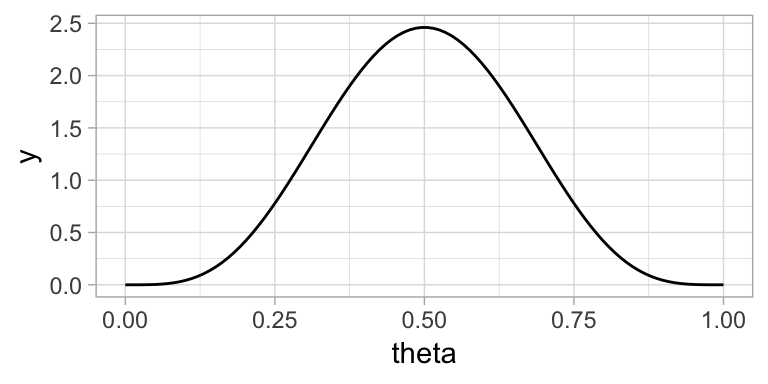

## Esimerkki - Kolikonheitto

- Tarkastellaan miten posteriorijakauma muuttuu heittosarjan koon kasvaessa
- Merkitään dataa \(y = (n,N-n)\) :
- Esim. \(y = (10,5)\) vastaa \(15\) heiton sarjaa, joista \(10\) klaavaa ja \(5\) kruunaa
- Tässä tapauksessa posteriorijakauma voidaan ilmaista analyyttisesti

\[ \begin{aligned} p(\theta \mid y = (n,N-n)) & \propto p(y=(n,N-n) \mid \theta) p(\theta) \\ & = \theta^{n}(1-\theta)^{N-n}\theta^4(1-\theta)^4 \\ & = \theta^{n+4}(1-\theta)^{N-n+4} \end{aligned} \]

## Esimerkki - Kolikonheitto

- Havaintojen määrän kasvaessa posteriorijakauma lähestyy uskottavuusfunktiota
  - Prioritodennäköisyyden merkitys vähenee

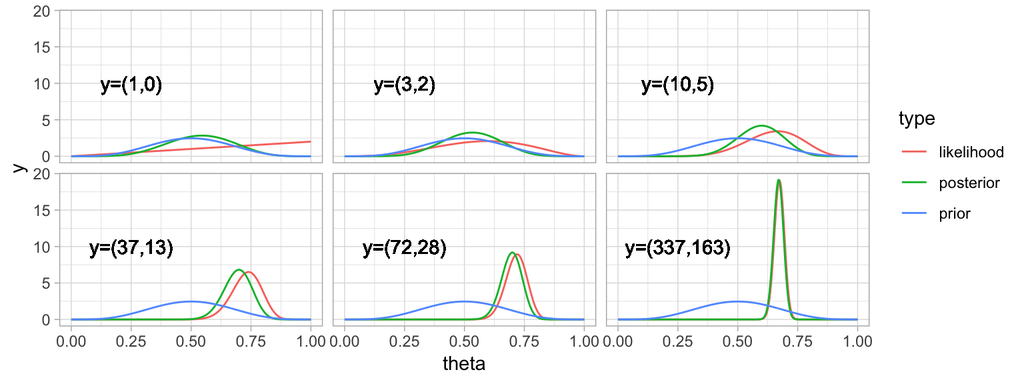

## Todennäköisyysväli

- Frekventistisen tilastotieteen luottamusväliä vastaava käsite Bayesilaisessa tilastotieteessa on **todennäköisyysväli**
- Ero frekventistiseen luottamusväliin on, että Bayesilaisen tulkinnan mukaisesti parametrin arvo kuuluu \(\alpha\)-todennäköisyysväliin todennäköisyydellä \(\alpha\)
- Määritelmän mukaisesti \(\alpha\)-todennäkäisyysväli (yleisemmin todennäköisyysalue) on mikä tahansa parametrijoukko, joka sisältää \(\alpha\) todennäköisyyttä \[p(\theta \in \Theta \mid x) = \alpha\]
- Käytännössä kyse on integraalista (tai summasta diskreetin satunnaismuuttujan tapauksessa) \[p(\theta \in \Theta \mid x) = \int_\Theta p(\theta \mid x) ~\mathsf{d} \theta = \alpha\]

## Todennäköisyysväli

- Todennäköisyysvälit eivät ole yksikäsitteisiä
  - Pienin väli/alue, joka sisältää \(\alpha\) todennäköisyyden
  - Väli, jonka alapuolelle jäävä todennäköisyys vastaa yläpuolelle jäävä todennäköisyyttä
  - Odotusarvon ollessa olemassa, väli joka on keskitetty odotusarvoon

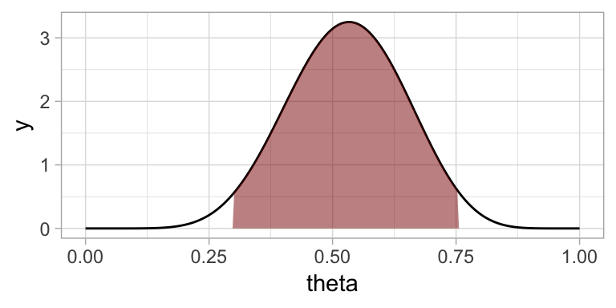

## Esimerkki - Kolikonheittoesimerkin todennäköisyysväli

- \(0.95\)-Todennäköisyysväli lyhenee havaintojen määrän kasvaessa

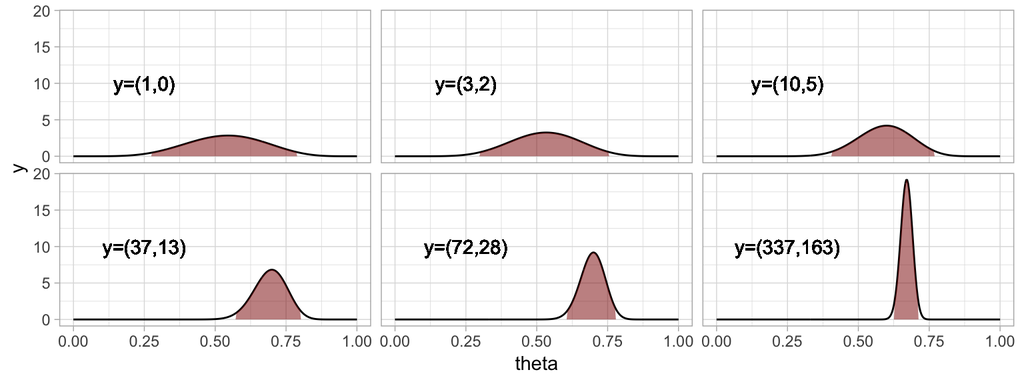

## Mallien vertailu

- Mallien vertailu tapahtuu mallien posterioritodennäköisyyden avulla
  - Vastaa likimääräisesti klassista hypoteesin testausta
- Jotta mallin \(M_i\) todennäköisyys voidaan laskea, tarvitaan malleille prioritodennäköisyydet \(p(M_i)\) kuten mille tahansa parametrille

\[\sum_{i=1}^m p(M_i) = 1\]

- Mallien posterioritodennäköisyydet ovat todennäköisyyksiä ja summautuvat todennäköisyydeksi \(1\)

\[\sum_{i=1}p(M_i \mid y) = 1\]

## Mallien vertailu

- Oletetaan, että mallin \(M_i\) määrittää sen parametrit \(\theta_i\)
- Tällöin mallin posterioritodennäköisyys lasketaan \[ p(M_i \mid y) = \frac{p(y \mid M_i) p(M_i)}{p(y)} \]
- Nyt mallin uskottavuus, **evidenssi**, lasketaan \[p(y \mid M_i) = \int p(y \mid \theta_i, M_i) ~ p(\theta_i \mid M_i) ~ \mathsf{d} \theta_i\]

## Mallien vertailu

- Mallien posterioritodennäköisyyksien suhde \[\frac{p(M_i \mid y)}{p(M_j \mid y)} = \frac{p(y \mid M_i)}{p(y \mid M_j)} \frac{p(M_i)}{p(M_j)}\]
- \(\frac{p(y \mid M_i)}{p(y \mid M_j)}\) on Bayesin faktori - mallittaa luonnollisesti Occamin partaterän efektiä

## Mallien vertailu

- Nykyisin käytetään usein mallien vertailuun posteriorijakauman laskemisen jälkeen Leave-one-out ristiinvalidointia
- Laskettava suure on \[\text{elpd}_\text{loo} = \sum_{i=1}^N \log p(y_i \mid y_{-i}) = \sum_{i=1}^N \log \int p(y_i \mid \theta)p(\theta \mid y_{-i}) \mathsf{d}\theta\]

## Prediktiiviset jakaumat

- Suureen \(\text{elpd}_\text{loo}\) laskemissa käytetään hyväksi prediktiivisiä jakaumia
- Prediktiivisiä jakaumia voidaan yleisemminkin hyödyntää havaintomallien sekä priorijakaumien järkevyyden tarkasteluun
- Nämä voidaan jakaa prioriprediktiivisiin sekä posterioriprediktiivisiin jakaumiin

## Prioriprediktiivinen jakauma

- Kun havaintomalli sekä tämän parametrien priorijakauma on mallitettu, minkälaista havaintoaineistoa malli ennustaa

\[p(y) = \int p(y \mid \theta) p(\theta) \mathsf{d} \theta\]

- Usein prioritieto liittyy nimenomaisesti tietämykseen mallin tuottamista realistisista arvoista
- Prioriprediktiivinen malli selventää parametrien priorijakauman vaikutusta havantoihin
  - Tuottavatko jotkut parametrikombinaatiot mahdottomia/hyvin epätodennäköisiä havaintoja?

## Posteoriprediktiivinen jakauma

- Kun havaintomalli sekä tämän parametrien priorijakauma on mallitettu ja posteriorijakauma on laskettu havaintoaineistoa käyttäen, minkälaista **uutta** havaintoaineistoa \(y^\prime\) malli ennustaa

\[ \begin{aligned} p(y^\prime \mid y) & = \int p(y^\prime \mid \theta, y) p(\theta \mid y) \mathsf{d} \theta \\ & = \int p(y^\prime \mid \theta) p(\theta \mid y) \mathsf{d} \theta \end{aligned} \]

- Posterioriprediktiivistä mallinnusta voidaan käyttää tarkastelemaan opittujen mallien järkevyyttä

## Bayesilainen analyysi käytännössä

- Posteriorijakauman laskeminen analyyttisessä muodossa onnistuu ainoastaan erikoistapauksissa
- Käytännössä laskeminen tapahtuu muodostamalla likimääräinen otosparvi posteriorijakaumasta
  - Importance sampling
  - Sequential Monte Carlo
  - Markov Chain Monte Carlo
  - **Hamiltonian Monte Carlo**

## Otosparvi posteriorijakauman estimaattina

- Otosparven avulla voidaan likimääräisesti laskea \(\mathsf{E}(g( \theta)\mid y)\) mille tahansa funktiolle \(g(\cdot)\)

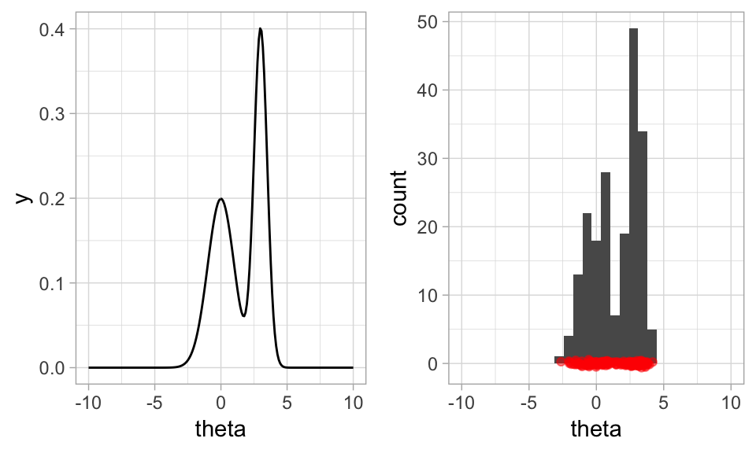

## Stan

- Nykyisin otoksen muodostaminen on yksinkertaista laajaltikäytettyjen ohjelmistojen ansiosta
- Suosituin ohjelmistoista on Stan
  - Stan
    - PyStan
    - RStan
- **rstanarm** : Bayesian applied regression modeling
  - R:stä tuttu käyttöliittymä Bayesilaisesta analyysista kiinnostuneille
  - Hyvin alhainen käyttökynnys

## rstanarm-esimerkki: Älykkyysosamäärän periytyminen

- Koodi rstanarm-vignettestä
- Sovitetaan yksinkertainen lineaarinen regressiomalli, jolla mallitetaan 3-4-vuotiaiden lasten ÄO:ta äitien ÄO:n sekä äitien high school-tutkintoa ilmaisevalla indikaattorimuuttujalla

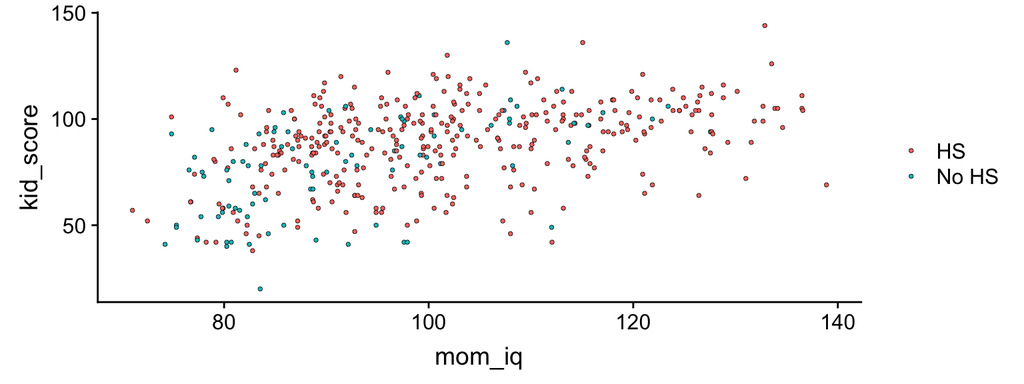

## rstanarm-esimerkki: Älykkyysosamäärän periytyminen

- rstanarm - koodi (oletusarvoisesti parametreille asetetaan normaalijakauma-priori)

```r
post1 <- stan_glm(kid_score ~ mom_hs, data = kidiq,
                  family = gaussian(link = "identity"))
post2 <- update(post1, formula = . ~ mom_iq)
post3 <- update(post1, formula = . ~ mom_hs + mom_iq)
post4 <- update(post1, formula = . ~ mom_hs * mom_iq)
posterior <- as.matrix(post4)
```

## rstanarm-esimerkki: Älykkyysosamäärän periytyminen

- Muuttujien posteriorimarginaalijakaumat

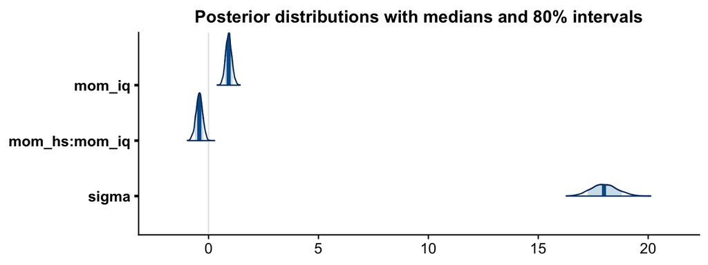

## rstanarm-esimerkki: Älykkyysosamäärän periytyminen

- Ryhmäerot äidin koulutuksen mukaisesti
- Malli post1:

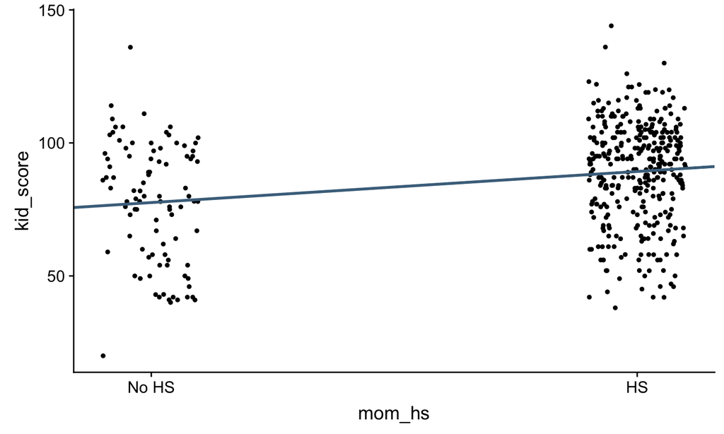

## rstanarm-esimerkki: Älykkyysosamäärän periytyminen

- Ryhmäerojen posteriorivarianssia voidaan havainnollistaa generoimalla posteriorijakaumasta
- Malli post1:

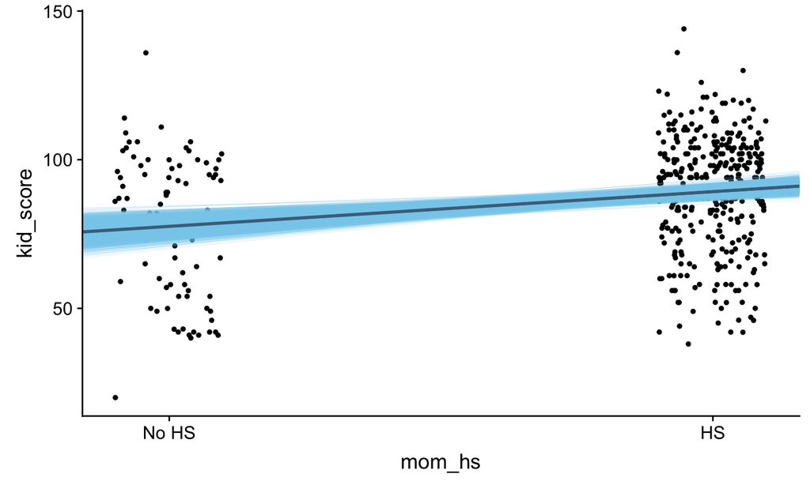

## rstanarm-esimerkki: Älykkyysosamäärän periytyminen

- Posteriorisovitteen vaihtelu
- Malli post2:

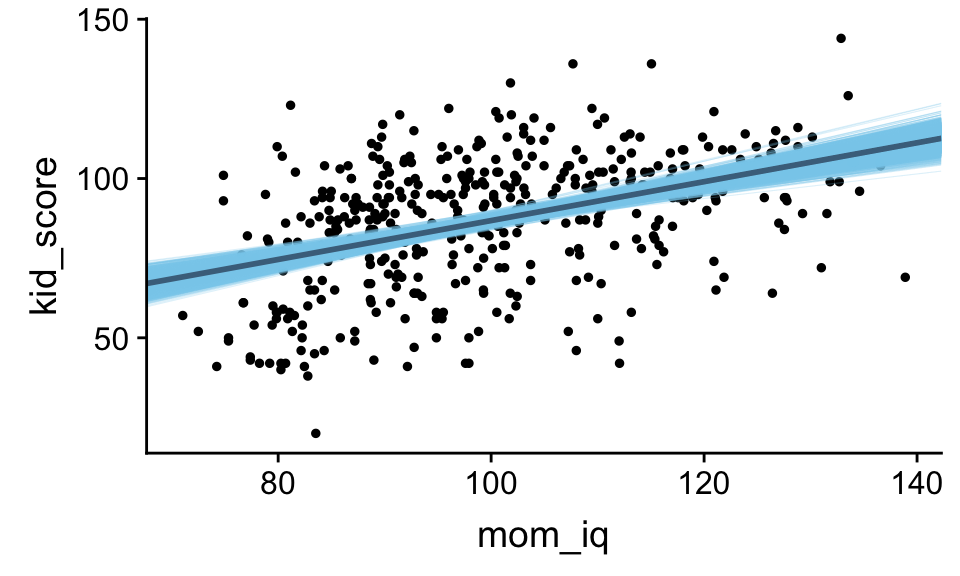

## rstanarm-esimerkki: Älykkyysosamäärän periytyminen

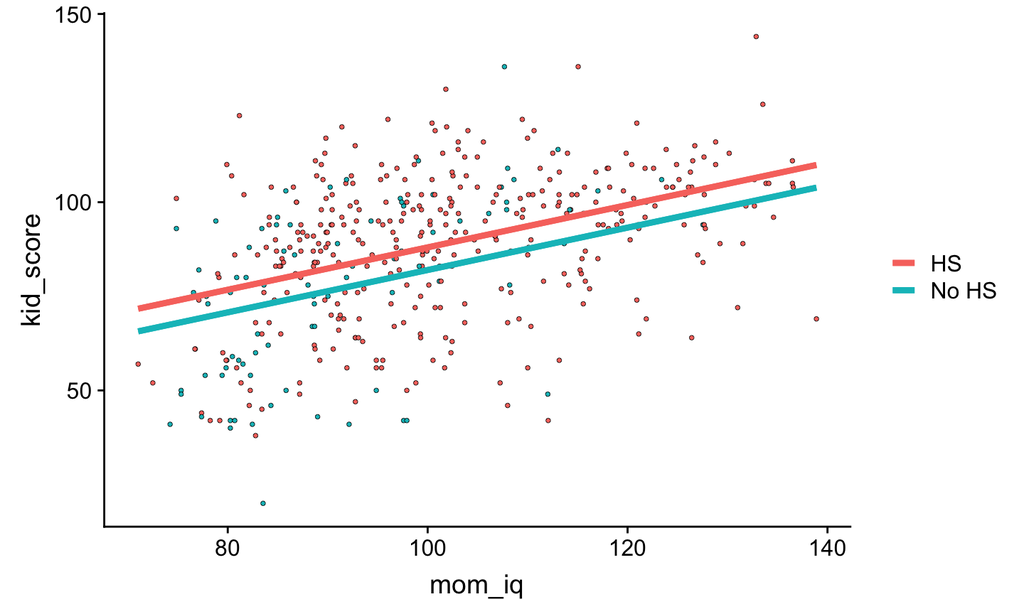

## rstanarm-esimerkki: Älykkyysosamäärän periytyminen

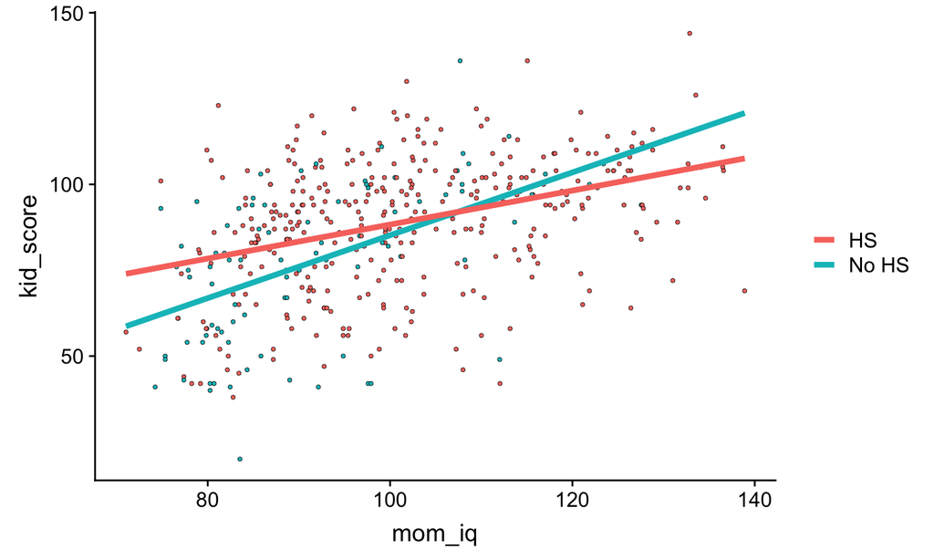

## rstanarm-esimerkki: Älykkyysosamäärän periytyminen

- Posteriorijakauman sovittamisen jälkeen kannattaa tarkastella havaintoaineiston jakaumaa, sekä posterioriprediktiivisestä jakaumasta generoitujen havaintoaineistojen jakaumia

## rstanarm-esimerkki: Älykkyysosamäärän periytyminen

- Malli post1

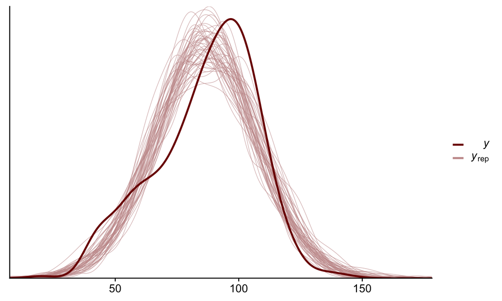

## rstanarm-esimerkki: Älykkyysosamäärän periytyminen

- Malli post2

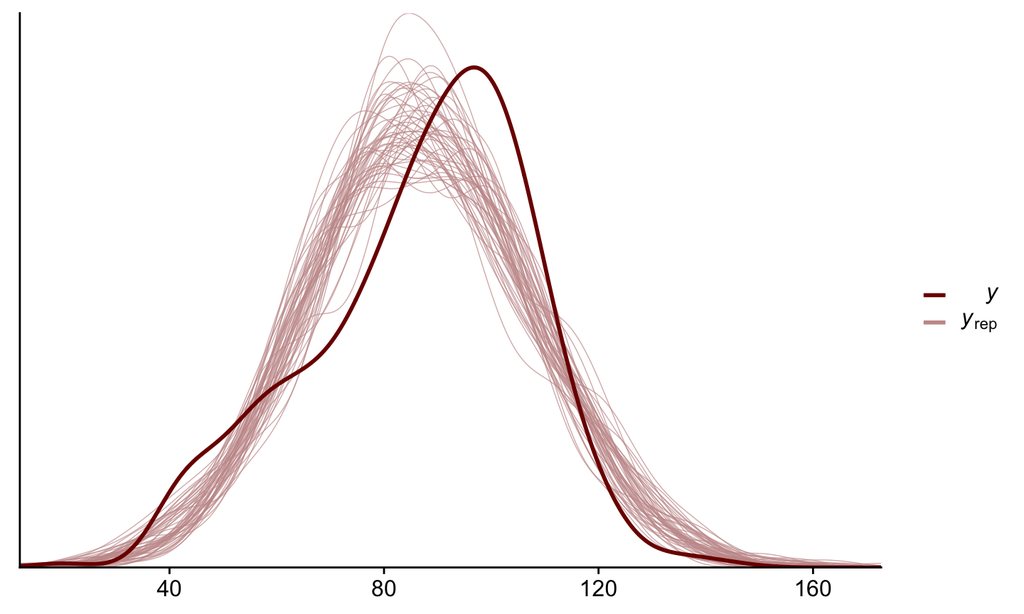

## rstanarm-esimerkki: Älykkyysosamäärän periytyminen

- Malli post3

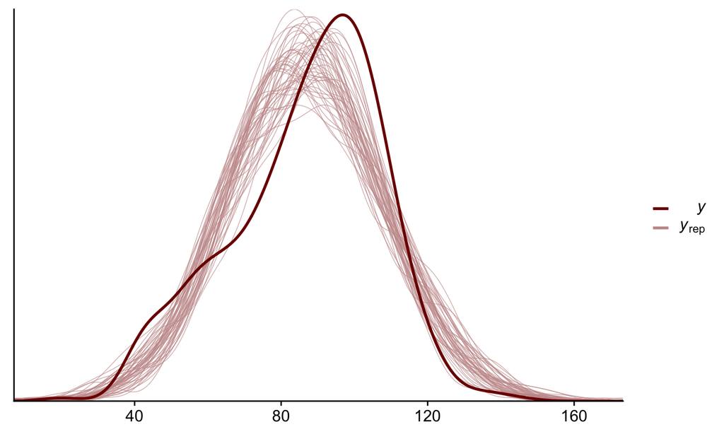

## rstanarm-esimerkki: Älykkyysosamäärän periytyminen

- Malli post4

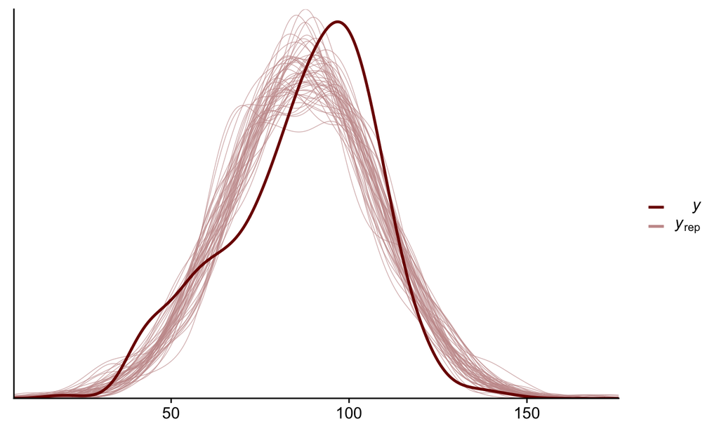

## rstanarm-esimerkki: Älykkyysosamäärän periytyminen

- Havaintoaineistosta lasketun tunnusluvun jakauma verrattuna posterioriprediktiivisiin tunnuslukuihin

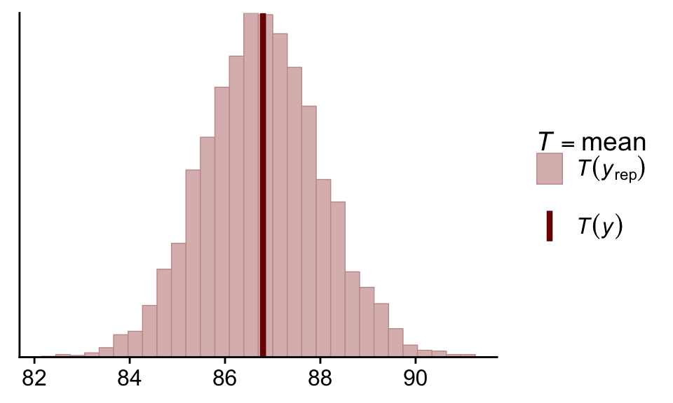

## rstanarm-esimerkki: Älykkyysosamäärän periytyminen

- Havaintoaineistosta laskettujen tunnuslukujen jakauma verrattuna posterioriprediktiivisiin tunnuslukuihin

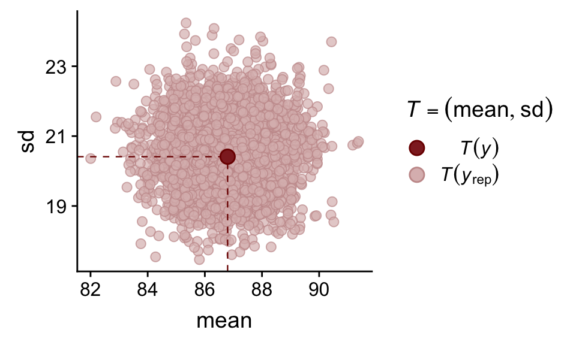

## rstanarm-esimerkki: Älykkyysosamäärän periytyminen

- Mallien vertailu kannattaa suorittaa leave-one-out-ristiinvalidoinnilla

```r
loo1 <- loo(post1); loo2 <- loo(post2);
loo3 <- loo(post3); loo4 <- loo(post4)
(comp <- compare_models(loo1, loo2, loo3, loo4))
```

```
##
## Model comparison:
## (ordered by highest ELPD)
##
##       elpd_diff se_diff
## post4   0.0       0.0
## post3  -3.5       2.5
## post2  -6.0       3.9
## post1 -42.3       8.7
```

## rstanarm-esimerkki: Älykkyysosamäärän periytyminen

- Posterioriprediktiiviset jakaumat ryhmittäin perustuen parhaiten havaintoaineistoon sopivaan malliin

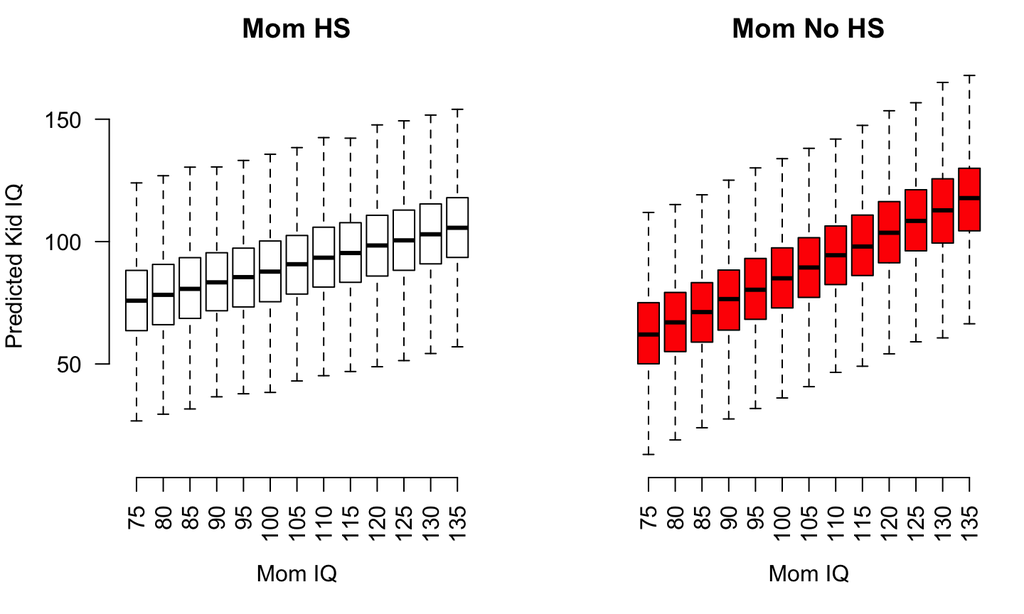

## Yhteenveto

- Bayesilaisessa päättelyssä todennäköisyys mallitetaan epävarmuutena maailman tilasta
  - Bayesian teoreema on työkalu prioritodennäköisyyksien päivittämiseen posterioritodennäköisyyksiksi
- Bayesilaiset menetelmat ovat käyttökelpoisia hyvin monenlaisissa päättelyongelmissa
  - Päättely perustuu posterioritodennäköisyyksiin
- Suurin käyttökynnys johtuu likimääräisestä laskennasta
  - Nykyisin ohjelmistot kuten Stan suorittavat laskennan automaattisesti

## Materiaalia

- mc-stan.org
- mc-stan.org/rstanarm/
- Bayesian Data Analysis : http://www.stat.columbia.edu/~gelman/book/
- Probability Theory: The Logic of Science : https://bayes.wustl.edu/etj/prob/book.pdf